# Original Homework Code

Christian Gagnon

9/16/2019

# Homework 02

This is the code for [homework 02](https://fuzzyatelin.github.io/bioanth-stats/homework-02.html), on week three of AN597. This id homewrok linked to module 6 and 7.

> Every Saturday morning, at the same time, a primatologist goes and sits in the forest to listen for titi monkey calls, counting the number of calls they hear in a 2 hour window from 5am to 7am. Based on previous knowledge, she believes that the mean number of calls she will hear in that time is exactly 15. Let X represent the appropriate Poisson random variable of the number of calls heard in each monitoring session.

Question 1: What is the probability that she will hear more than 8 calls during any given session?

```r
1-ppois(8,15)
```

```
## [1] 0.9625535
```

Question 2: What is the probability that she will hear no calls in a session?

```r
ppois(0,15)
```

```
## [1] 3.059023e-07
```

Question 3:What is the probability that she will hear exactly 3 calls in a session?

```r
ppois(3,15)-ppois(2,15)
```

```
## [1] 0.0001720701
```

Question 4: Plot the relevant Poisson mass function over the values in range 0 ≤ x ≤ 30.

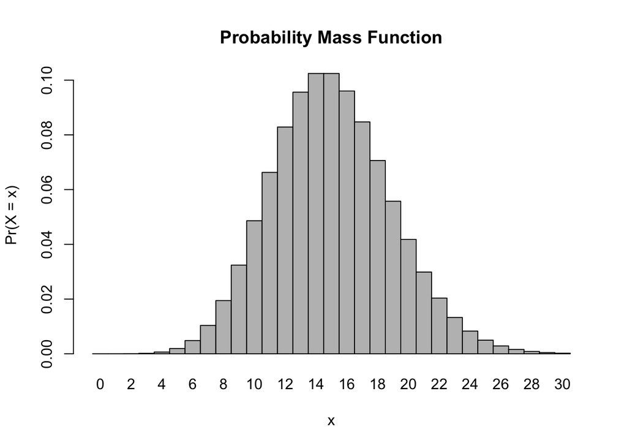

```r
x <- 0:30
l = 15
probset<-dpois(x=x,lambda=l)
barplot(probset,names.arg=x,space=0,xlab="x",ylab="Pr(X = x)",main="Probability Mass Function")
```

Question 5: Simulate 104 results from this distribution (i.e., 2 years of Saturday monitoring sessions).

```r
y<-rpois(104,15)
y
```

```
##   [1] 21 10 26 14 21 17 15 22 20 11 14 14 19 13 19 17 11 15 15 10 15 20 11
##  [24]  7 21 12 13 16 15 11 11 15  9 16 19 18 16 19 18 15 10 10 13 22  9  8
##  [47] 10 20 21 16 21 15 12 10 12 14  9 22 21  9 14 15 13  8 13 14 14 19 18
##  [70] 17 14 20 15 17 13 21 18 13  8 19 11 20 17  8 11 18 13 11 16 15 19 22
##  [93] 19 12 16 16  8 17  9 13 13 14 26 22
```

Question 6: Plot the simulated results using hist() and use xlim() to set the horizontal limits to be from 0 to 30. How does your histogram compare to the shape of the probability mass function you plotted above?

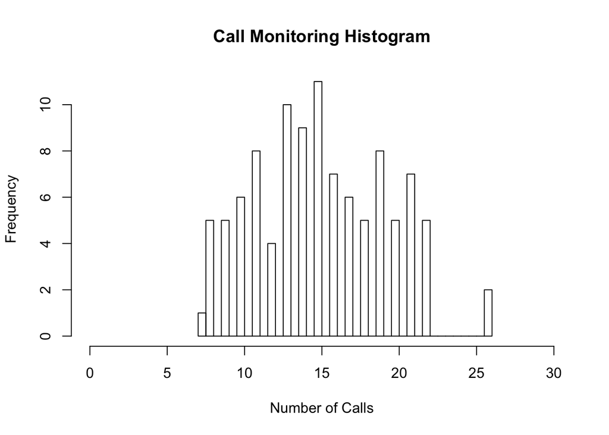

```r
hist(y,xlim=c(0,30),xlab="Number of Calls",main="Call Monitoring Histogram",breaks=30)
```

## Challenges

1. It was hard
2. I’m not that smart